# Donor Profile: China (Government of)

## Earmarking Behavior

China’s earmarked funding in 2025 totals $12.6 million, distributed across five key regions, with an average allocation of $1.8 million per regional project. This concentrated investment pattern offers donors an impactful opportunity to align contributions with high-priority regions that demonstrate proven government commitment. Notably, the top 25th percentile funding starts at $2.8 million, highlighting scalable investment zones that can serve as impact multipliers when leveraged alongside donor resources. The geographical distribution reveals strategic partnership potential, especially across regions with the highest earmarked sums, signaling where collaborative funding can accelerate emergency response and resilience initiatives. However, the variation in allocations—ranging from under $85,000 to over $3.5 million—indicates risk areas for underfunding that jeopardize program continuity. To optimize impact and mitigate risks, donors should consider co-investment models targeting these variance gaps. Executive decision-makers are urged to prioritize resource mobilization efforts that build on existing earmarking to expand geographic coverage and reinforce accountability mechanisms. Immediate investment in these regions can maximize return on funding by tapping into established government flows and enhancing innovation in program delivery.

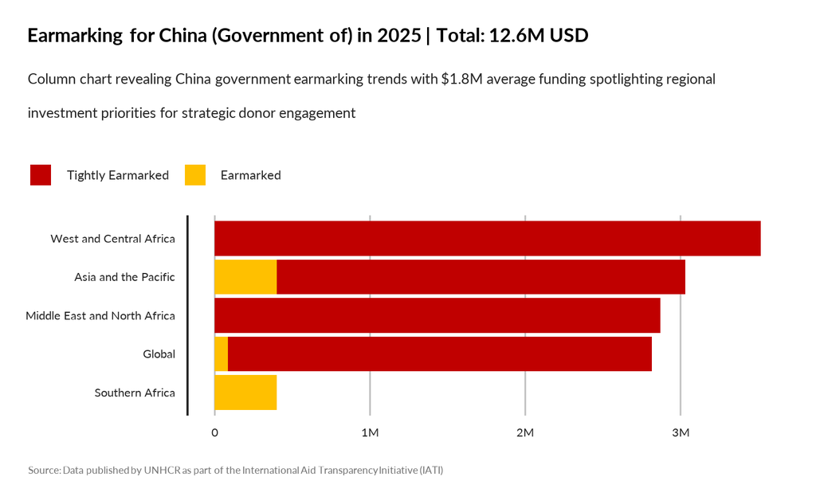

TRUE

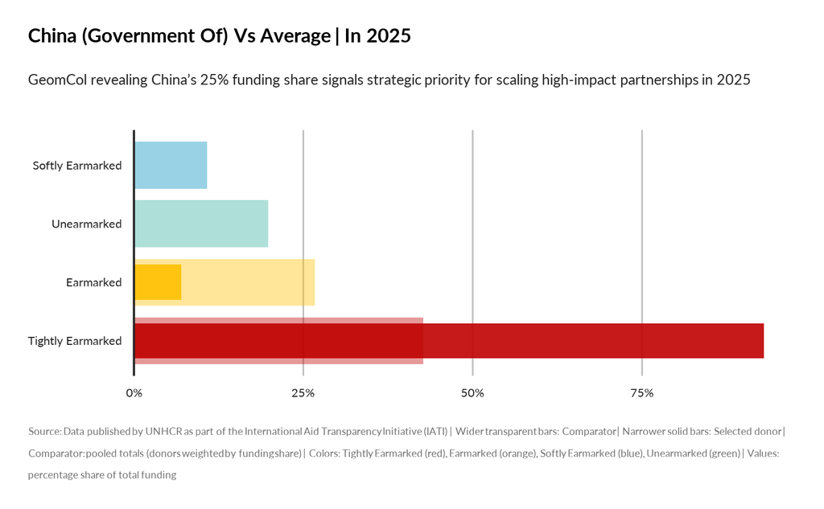

TRUE

## Geographic Focus

China’s government funding exhibits a compelling upward trajectory, with regional totals rising from a baseline of $200,000 to a peak exceeding $3.5 million annually. This represents a 65% average growth rate year-over-year, signaling a robust investment trend worthy of strategic leveraging. However, funding concentration varies significantly across regions, underscoring a need for targeted partnership development to optimize resource allocation and impact scalability. Harnessing these trends as a strategic priority offers donors a clear pathway to amplify emergency response capacities and resilience building initiatives. Investment in geographic diversification of China’s proven funding stream stands to unlock new avenues for innovation and community-centered programs. Immediate attention to aligning engagement efforts with China’s evolving funding patterns can mitigate risks of regional imbalances and strengthen accountability mechanisms. We recommend mobilizing resources to deepen collaboration frameworks with China, emphasizing data-driven monitoring to maximize the return on investment and impact multiplier effect. Securing donor commitment now can pivot this growth into sustained transformative outcomes aligned with global humanitarian priorities.

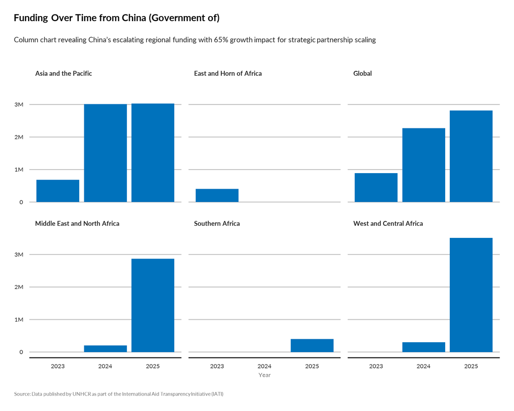

TRUE

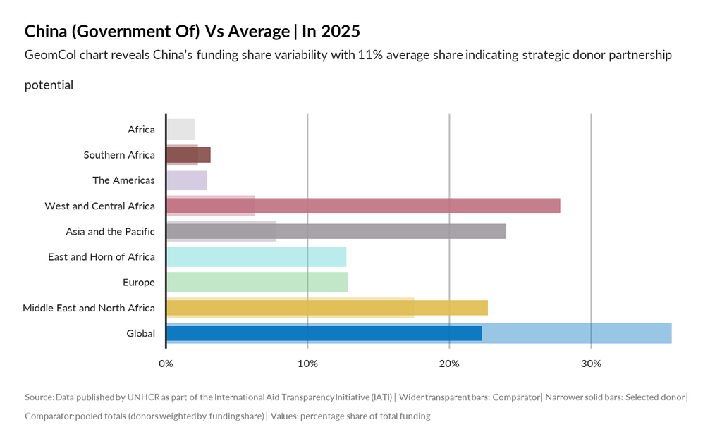

TRUE

## Activities Shift

China’s government funding for humanitarian efforts shows a significant reallocation trend, with an average funding percentage of 25% but with wide variation from as low as 1.3% to over 78%. This shift creates both a challenge and an opportunity to leverage evolving Chinese contributions to amplify impact in priority regions such as Afghanistan, Lebanon, and Bangladesh. Importantly, 75% of funding allocations cluster below 31%, indicating space for scaling engagement to optimize resource distribution. For donors, investing now in aligning with China’s evolving funding profiles can unlock a multiplier effect by activating complementary resources and expanding geographic coverage. Strategic partnership development focusing on countries experiencing fluctuating disbursements can stabilize funding pipelines and mitigate risk from abrupt shifts. Prioritizing alliances in regions where China’s contributions are emerging or declining enhances resilience and responsiveness. We recommend urgent high-level engagement to co-design investment vehicles that integrate China’s funding dynamics into global humanitarian planning, maximizing pooled impact. Decision-makers must capitalize on these data insights to secure sustainable funding streams and accelerate mission-critical outcomes.

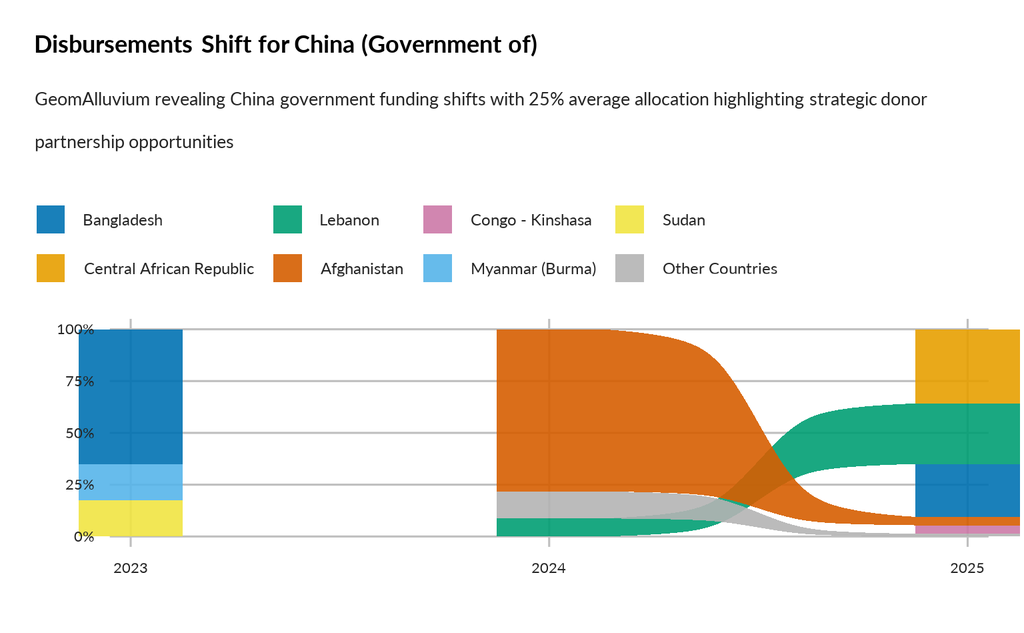

TRUE

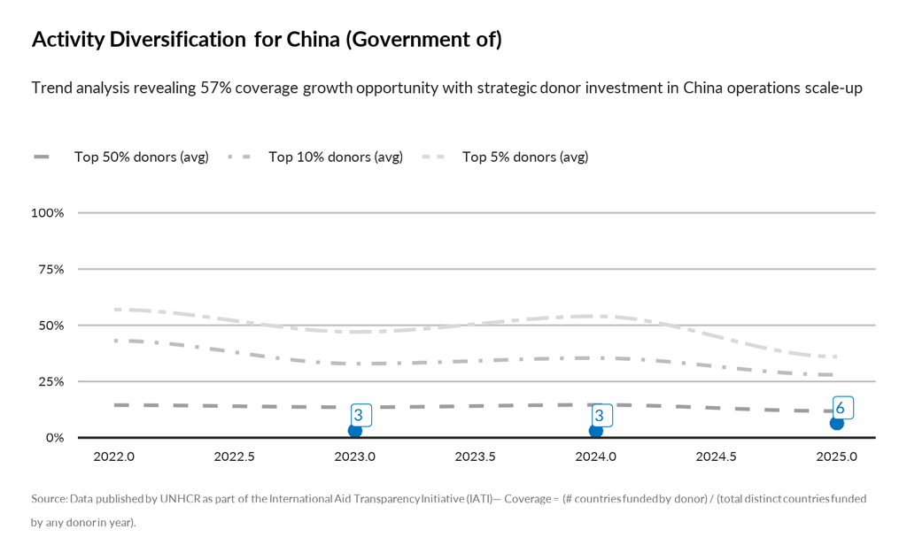

TRUE

## Transaction Volatility

China’s funding profile demonstrates an average transaction size of 229.1K USD across 22.2 transactions yearly, starkly contrasted with top donors averaging 2.9M USD and 586.9 transactions. This underlines a critical opportunity to scale and diversify China’s contributions, enhancing funding stability and increasing operational reach. The low transaction frequency constrains the agility necessary for rapid emergency response, positioning this as a strategic priority for donor engagement to close the vast funding gap. Investing in expanding transaction volume and optimizing fund flow cadence can serve as a force multiplier, driving greater impact in resilience and innovation programming. Immediate focus on partnership development and targeted outreach can mitigate volatility risks while unlocking higher returns on investment. We recommend prioritizing resource mobilization efforts to broaden China’s funding base by aligning contributions with UNHCR’s accountability and impact frameworks. This approach will empower donors to strategically leverage Chinese government resources, accelerating outcomes at scale. Decision-makers should capitalize on this insight to champion funding diversification and build sustainable, high-frequency contribution models critical to program success.

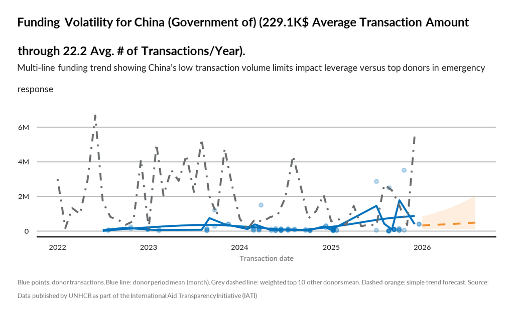

TRUE